# Module 71

#### Hemi-module gene counts:

383 probesets in hemi-module A.  
2 probesets in hemi-module B.  
Note: While the mapping of probesets to genes is usually one-to-one, some genes are targeted by multiple probesets, some probesets target multiple genes, and some probesets do not target any genes (i.e., the region of the genome they match is no longer considered genic).

#### Contrast SVE:

Signed variance explained (SVE) provides an indication of how similar a set of fold changes are to a gene module’s weight vector. An SVE value of 0.3, for example, indicates that 30% of the variance explained by the entire module set is accounted for by the module in question. Shown here are the SVE values for this module across a compendium of fold changes (contrasts). Extreme SVE values (e.g., > 0.05) indicate that those contrasts specifically induce (orange dots) or specifically repress (blue dots) this module. Examining the experimental conditions being compared in such contrasts (see tables below the figure) may provide insight into the gene module’s function.

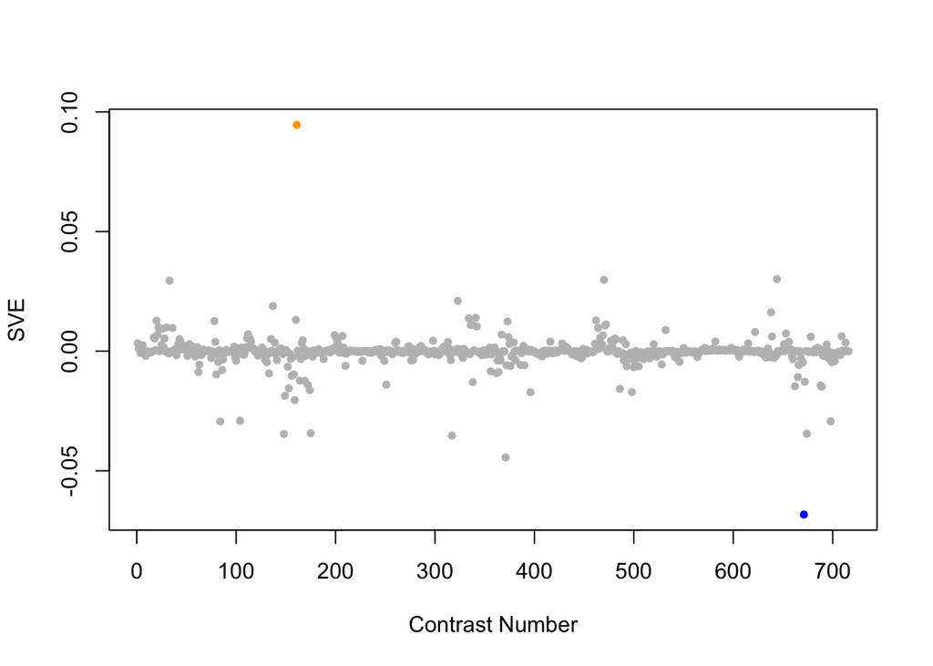

Positive SVE Contrasts:

|  | Contrast.Num | SVE | GEO.GSE | Cond.1 | Cond.2 | Mutation |
| --- | --- | --- | --- | --- | --- | --- |
| GSE47778.s4t2.vs.s3t2 | 161 | 0.09 | GSE47778 | daf-2;daf-16; starvation; replicate 1 | daf-16; starvation; replicate 1 | daf-2;daf-16 vs. daf-16 |
| GSE16915.s1t1.vs.s3t1 | 644 | 0.03 | GSE16915 | control sample | bio-electrosprayed sample |  |
| GSE23528A.s2t6.vs.s0t6 | 470 | 0.03 | GSE23528 | Adult at T22 in WC, time-series experiment 1 | Adult at T22, non-entrained control time-series experiment 4 |  |
| GSE9665.s12t2.vs.s0t2 | 33 | 0.03 | GSE9665 | mex-3 vab-7 186 A | mex-3 186 A | vab-7 |
| GSE38997.s3t3.vs.s2t3 | 323 | 0.02 | GSE38997 | experiment 1 UVC- and EtBr-exposed samples at 48 h 1eu48 | experiment 1 EtBr-exposed samples at 48 h 1e48 |  |

Negative SVE Contrasts:

|  | Contrast.Num | SVE | GEO.GSE | Cond.1 | Cond.2 | Mutation |
| --- | --- | --- | --- | --- | --- | --- |
| GSE15016.s1t1.vs.s0t1 | 671 | -0.07 | GSE15016 | young adult_24hr AgNPs exposure_rep1 | young adult_not exposured_rep1 |  |
| GSE35360C.s1t1.vs.s0t1 | 371 | -0.04 | GSE35360 | HFHQ 3d_0.2_rep1 | HFHQ 3d control_rep1 |  |
| GSE39145.s1t1.vs.s0t1 | 317 | -0.04 | GSE39145 | ercc-1_I | wild-type_N2_I | ercc-1 |
| GSE48347.s2t1.vs.s0t1 | 148 | -0.03 | GSE48347 | sdc2_embryo_rep1 | WT_embryo_rep1 | sdc-2 |
| GSE14640C.s1t1.vs.s0t1 | 674 | -0.03 | GSE14640 | XX_SDC2Y93R-P-022208_A | XX_WT-P_081407_A |  |

$~$

#### Contrast SVE, Up-Regulated Genes Only:

Calculating SVE for up-regulated and down-regulated genes separately may be more informative in many cases than projecting the up- and down- gene sets together. This is due to the fact that the weight distribution of many modules is highly skewed, indicating that only one of the hemi-modules may be biologically meaningful (i.e., a set of genes are strongly correlated by only a few genes (or none) are strongly anti-correlated to that set.)

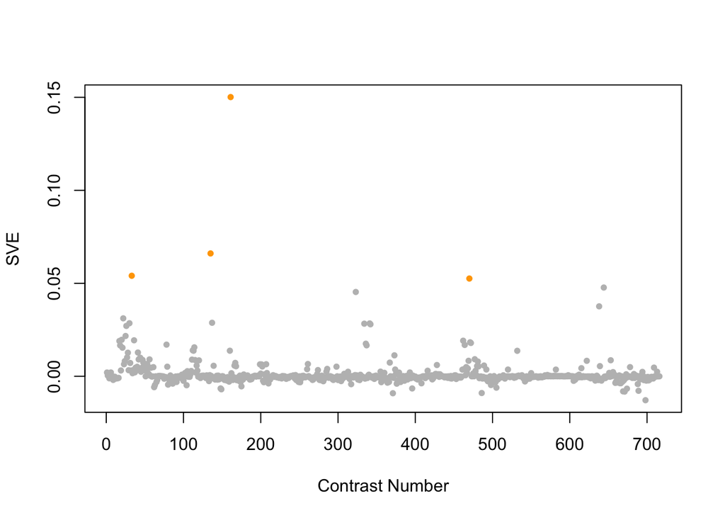

Positive SVE Contrasts:

|  | Contrast.Num | SVE | GEO.GSE | Cond.1 | Cond.2 | Mutation |
| --- | --- | --- | --- | --- | --- | --- |
| GSE47778.s4t2.vs.s3t2 | 161 | 0.15 | GSE47778 | daf-2;daf-16; starvation; replicate 1 | daf-16; starvation; replicate 1 | daf-2;daf-16 vs. daf-16 |
| GSE52064.s1t1.vs.s2t1 | 135 | 0.07 | GSE52064 | wildtype_1 | mes-4_1 | mes-4 |
| GSE9665.s12t2.vs.s0t2 | 33 | 0.05 | GSE9665 | mex-3 vab-7 186 A | mex-3 186 A | vab-7 |
| GSE23528A.s2t6.vs.s0t6 | 470 | 0.05 | GSE23528 | Adult at T22 in WC, time-series experiment 1 | Adult at T22, non-entrained control time-series experiment 4 |  |
| GSE16915.s1t1.vs.s3t1 | 644 | 0.05 | GSE16915 | control sample | bio-electrosprayed sample |  |

Negative SVE Contrasts:

|  | Contrast.Num | SVE | GEO.GSE | Cond.1 | Cond.2 | Mutation |
| --- | --- | --- | --- | --- | --- | --- |
| GSE11055.s3t4.vs.s2t4 | 698 | -0.01 | GSE11055 | L1 larvae 3 hr after hatching in the absence of food in the alternative starvation buffer M9 | L1 larvae 3 hr after hatching in the absence of food |  |
| GSE35360C.s1t1.vs.s0t1 | 371 | -0.01 | GSE35360 | HFHQ 3d_0.2_rep1 | HFHQ 3d control_rep1 |  |
| GSE23528A.s0t6.vs.s0t1 | 486 | -0.01 | GSE23528 | Adult at T22, non-entrained control time-series experiment 4 | Adult at T2, non-entrained control time-series experiment 4 |  |
| GSE15016.s1t1.vs.s0t1 | 671 | -0.01 | GSE15016 | young adult_24hr AgNPs exposure_rep1 | young adult_not exposured_rep1 |  |
| GSE15016.s3t1.vs.s0t1 | 669 | -0.01 | GSE15016 | young adult_24hr DEHP exposure_rep1 | young adult_not exposured_rep1 |  |

$~$

#### Contrast SVE, Down-Regulated Genes Only:

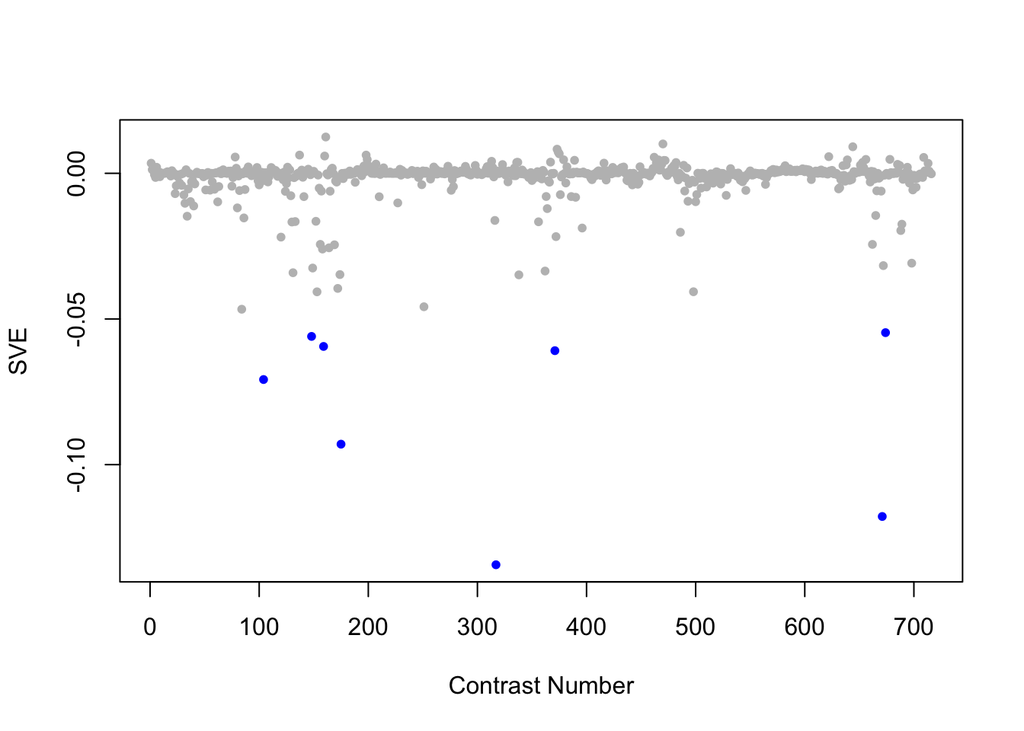

Positive SVE Contrasts:

|  | Contrast.Num | SVE | GEO.GSE | Cond.1 | Cond.2 | Mutation |
| --- | --- | --- | --- | --- | --- | --- |
| GSE47778.s4t2.vs.s3t2 | 161 | 0.01 | GSE47778 | daf-2;daf-16; starvation; replicate 1 | daf-16; starvation; replicate 1 | daf-2;daf-16 vs. daf-16 |
| GSE23528A.s2t6.vs.s0t6 | 470 | 0.01 | GSE23528 | Adult at T22 in WC, time-series experiment 1 | Adult at T22, non-entrained control time-series experiment 4 |  |
| GSE16915.s1t1.vs.s3t1 | 644 | 0.01 | GSE16915 | control sample | bio-electrosprayed sample |  |
| GSE35354A.s1t3.vs.s1t1 | 373 | 0.01 | GSE35354 | Q100_rep1 | Q control_rep1 |  |
| GSE35354A.s1t4.vs.s1t1 | 374 | 0.01 | GSE35354 | Q200_rep1 | Q control_rep1 |  |

Negative SVE Contrasts:

|  | Contrast.Num | SVE | GEO.GSE | Cond.1 | Cond.2 | Mutation |
| --- | --- | --- | --- | --- | --- | --- |
| GSE39145.s1t1.vs.s0t1 | 317 | -0.13 | GSE39145 | ercc-1_I | wild-type_N2_I | ercc-1 |
| GSE15016.s1t1.vs.s0t1 | 671 | -0.12 | GSE15016 | young adult_24hr AgNPs exposure_rep1 | young adult_not exposured_rep1 |  |
| GSE47778.s5t3.vs.s1t3 | 175 | -0.09 | GSE47778 | xpa-1 10mJ/cm2; replicate 1 | N2; UV; replicate 1 | xpa-1 |
| GSE57664.s1t1.vs.s0t1 | 104 | -0.07 | GSE57664 | TYR treated rep1 | control rep1 |  |
| GSE35360C.s1t1.vs.s0t1 | 371 | -0.06 | GSE35360 | HFHQ 3d_0.2_rep1 | HFHQ 3d control_rep1 |  |
| GSE47778.s5t1.vs.s1t1 | 159 | -0.06 | GSE47778 | xpa-1 0mJ/cm2; replicate 1 | N2; replicate 1 | xpa-1 |
| GSE48347.s2t1.vs.s0t1 | 148 | -0.06 | GSE48347 | sdc2_embryo_rep1 | WT_embryo_rep1 | sdc-2 |
| GSE14640C.s1t1.vs.s0t1 | 674 | -0.05 | GSE14640 | XX_SDC2Y93R-P-022208_A | XX_WT-P_081407_A |  |

$~$

$~$

#### GO Term Enrichment:

This analysis tests each hemi-module for enrichment of specific GO terms. Only gene-level annotations (e.g., as would be found on the gene’s page in Wormbase) are tested - the hierarchical structure of the GO ontology is not taken into account.

*Note: At least the top two most enriched terms from each GO domain (BP/MF/CC) are shown, even when not statistically significant.*

##### Enriched GO terms: Hemi-module A

| ID | GO.Term | GO Domain | Raw p-value | Adj p-value |
| --- | --- | --- | --- | --- |
| [GO_0006397](http://amigo.geneontology.org/amigo/term/GO:0006397) | mRNA processing | BP | 3.39e-06 | 1.24e-02 |
| [GO_0042254](http://amigo.geneontology.org/amigo/term/GO:0042254) | ribosome biogenesis | BP | 1.89e-05 | 3.44e-02 |
| [GO_0007506](http://amigo.geneontology.org/amigo/term/GO:0007506) | gonadal mesoderm development | BP | 7.90e-05 | 7.19e-02 |
| [GO_0060298](http://amigo.geneontology.org/amigo/term/GO:0060298) | positive regulation of sarcomere organization | BP | 7.90e-05 | 7.19e-02 |
| [GO_0006468](http://amigo.geneontology.org/amigo/term/GO:0006468) | protein phosphorylation | BP | 9.87e-05 | 7.19e-02 |
| [GO_0005515](http://amigo.geneontology.org/amigo/term/GO:0005515) | protein binding | MF | 1.89e-07 | 2.82e-04 |
| [GO_0000166](http://amigo.geneontology.org/amigo/term/GO:0000166) | nucleotide binding | MF | 2.76e-07 | 2.82e-04 |
| [GO_0005524](http://amigo.geneontology.org/amigo/term/GO:0005524) | ATP binding | MF | 2.47e-06 | 1.68e-03 |
| [GO_0004652](http://amigo.geneontology.org/amigo/term/GO:0004652) | polynucleotide adenylyltransferase activity | MF | 1.69e-04 | 7.33e-02 |
| [GO_0004674](http://amigo.geneontology.org/amigo/term/GO:0004674) | protein serine/threonine kinase activity | MF | 1.79e-04 | 7.33e-02 |
| [GO_0017022](http://amigo.geneontology.org/amigo/term/GO:0017022) | myosin binding | MF | 2.92e-04 | 9.93e-02 |
| [GO_0016021](http://amigo.geneontology.org/amigo/term/GO:0016021) | integral component of membrane | CC | 1.67e-18 | 1.55e-15 |
| [GO_0016020](http://amigo.geneontology.org/amigo/term/GO:0016020) | membrane | CC | 2.27e-14 | 1.05e-11 |
| [GO_0005634](http://amigo.geneontology.org/amigo/term/GO:0005634) | nucleus | CC | 2.20e-10 | 6.82e-08 |
| [GO_0005737](http://amigo.geneontology.org/amigo/term/GO:0005737) | cytoplasm | CC | 3.65e-10 | 8.47e-08 |
| [GO_0005730](http://amigo.geneontology.org/amigo/term/GO:0005730) | nucleolus | CC | 1.32e-04 | 2.45e-02 |
| [GO_0030688](http://amigo.geneontology.org/amigo/term/GO:0030688) | preribosome, small subunit precursor | CC | 6.79e-04 | 9.00e-02 |
| [GO_0031672](http://amigo.geneontology.org/amigo/term/GO:0031672) | A band | CC | 6.79e-04 | 9.00e-02 |

##### Enriched GO terms: Hemi-module B

| ID | GO.Term | GO Domain | Raw p-value | Adj p-value |
| --- | --- | --- | --- | --- |
| [GO_0006679](http://amigo.geneontology.org/amigo/term/GO:0006679) | glucosylceramide biosynthetic process | BP | 3.32e-04 | 1.00e+00 |
| [GO_0006665](http://amigo.geneontology.org/amigo/term/GO:0006665) | sphingolipid metabolic process | BP | 2.91e-03 | 1.00e+00 |
| [GO_0102769](http://amigo.geneontology.org/amigo/term/GO:0102769) | dihydroceramide glucosyltransferase activity | MF | 2.49e-04 | 3.40e-01 |
| [GO_0008120](http://amigo.geneontology.org/amigo/term/GO:0008120) | ceramide glucosyltransferase activity | MF | 3.32e-04 | 3.40e-01 |
| [GO_0016021](http://amigo.geneontology.org/amigo/term/GO:0016021) | integral component of membrane | CC | 4.00e-01 | 1.00e+00 |
| [GO_0016020](http://amigo.geneontology.org/amigo/term/GO:0016020) | membrane | CC | 4.26e-01 | 1.00e+00 |

$~$

$~$

#### Tissue Enrichment:

This analysis tests each hemi-module for enrichment of genes associated with anatomy terms. Negative enrichment scores indicate fewer hemi-module genes than expected by random chance were associated with the anatomy term in question.

##### Enriched tissues: Hemi-module A

No significant annotations.

##### Enriched tissues: Hemi-module B

No significant annotations.

$~$

$~$

#### HOMER promoter motif enrichment:

This analysis tests each hemi-module for enrichment of 108 known *C. elegans* transcription factor binding site motifs (see [108 CE motifs](https://katiepod.github.io//all.worm.motifs.html)) using the HOMER (Hypergeometric Optimization of Motif EnRichment) software (see [PMID:20513432](https://pubmed.ncbi.nlm.nih.gov/20513432)). HOMER was run using default parameters on sequences 1 kb upstream of the transcription start site.

##### Motif enrichment: Hemi-module A

Total target sequences = 290  
Total background sequences = 36955  
* - possible false positive

Rank

Motif

P-value

log P-pvalue

% of Targets

% of Background

STD(Bg STD)

Best Match/Details

Motif File

1

[figure not shown]

1e-13

-3.197e+01

30.34%

12.99%

283.4bp (379.7bp)

blmp-1/MA0537.1/Jaspar(0.727)  
[More Information](https://katiepod.github.io/HomerResults/m71_a_hemi_genes.txt.out.1kb/homerResults/motif1.info.html) | [Similar Motifs Found](https://katiepod.github.io/HomerResults/m71_a_hemi_genes.txt.out.1kb/homerResults/motif1.similar.html)

[motif file (matrix)](https://katiepod.github.io/HomerResults/m71_a_hemi_genes.txt.out.1kb/homerResults/motif1.motif)

2

[figure not shown]

1e-13

-2.996e+01

33.45%

15.72%

272.0bp (354.7bp)

blmp-1/MA0537.1/Jaspar(0.630)  
[More Information](https://katiepod.github.io/HomerResults/m71_a_hemi_genes.txt.out.1kb/homerResults/motif2.info.html) | [Similar Motifs Found](https://katiepod.github.io/HomerResults/m71_a_hemi_genes.txt.out.1kb/homerResults/motif2.similar.html)

[motif file (matrix)](https://katiepod.github.io/HomerResults/m71_a_hemi_genes.txt.out.1kb/homerResults/motif2.motif)

3 *

[figure not shown]

1e-10

-2.366e+01

24.48%

10.85%

294.5bp (356.1bp)

zip-8/MA1704.1/Jaspar(0.571)  
[More Information](https://katiepod.github.io/HomerResults/m71_a_hemi_genes.txt.out.1kb/homerResults/motif3.info.html) | [Similar Motifs Found](https://katiepod.github.io/HomerResults/m71_a_hemi_genes.txt.out.1kb/homerResults/motif3.similar.html)

[motif file (matrix)](https://katiepod.github.io/HomerResults/m71_a_hemi_genes.txt.out.1kb/homerResults/motif3.motif)

4 *

[figure not shown]

1e-9

-2.219e+01

28.62%

14.24%

242.0bp (371.6bp)

ceh-48/MA0921.1/Jaspar(0.700)  
[More Information](https://katiepod.github.io/HomerResults/m71_a_hemi_genes.txt.out.1kb/homerResults/motif4.info.html) | [Similar Motifs Found](https://katiepod.github.io/HomerResults/m71_a_hemi_genes.txt.out.1kb/homerResults/motif4.similar.html)

[motif file (matrix)](https://katiepod.github.io/HomerResults/m71_a_hemi_genes.txt.out.1kb/homerResults/motif4.motif)

5 *

[figure not shown]

1e-9

-2.213e+01

4.48%

0.38%

341.0bp (385.8bp)

efl-1/MA0541.1/Jaspar(0.551)  
[More Information](https://katiepod.github.io/HomerResults/m71_a_hemi_genes.txt.out.1kb/homerResults/motif5.info.html) | [Similar Motifs Found](https://katiepod.github.io/HomerResults/m71_a_hemi_genes.txt.out.1kb/homerResults/motif5.similar.html)

[motif file (matrix)](https://katiepod.github.io/HomerResults/m71_a_hemi_genes.txt.out.1kb/homerResults/motif5.motif)

6 *

[figure not shown]

1e-9

-2.206e+01

31.03%

16.12%

293.5bp (325.6bp)

zip-8/MA1704.1/Jaspar(0.695)  
[More Information](https://katiepod.github.io/HomerResults/m71_a_hemi_genes.txt.out.1kb/homerResults/motif6.info.html) | [Similar Motifs Found](https://katiepod.github.io/HomerResults/m71_a_hemi_genes.txt.out.1kb/homerResults/motif6.similar.html)

[motif file (matrix)](https://katiepod.github.io/HomerResults/m71_a_hemi_genes.txt.out.1kb/homerResults/motif6.motif)

7 *

[figure not shown]

1e-9

-2.177e+01

38.62%

22.31%

293.6bp (420.8bp)

fkh-9/MA1440.1/Jaspar(0.566)  
[More Information](https://katiepod.github.io/HomerResults/m71_a_hemi_genes.txt.out.1kb/homerResults/motif7.info.html) | [Similar Motifs Found](https://katiepod.github.io/HomerResults/m71_a_hemi_genes.txt.out.1kb/homerResults/motif7.similar.html)

[motif file (matrix)](https://katiepod.github.io/HomerResults/m71_a_hemi_genes.txt.out.1kb/homerResults/motif7.motif)

8 *

[figure not shown]

1e-9

-2.116e+01

9.66%

2.36%

281.1bp (325.2bp)

POL012.1_TATA-Box/Jaspar(0.575)  
[More Information](https://katiepod.github.io/HomerResults/m71_a_hemi_genes.txt.out.1kb/homerResults/motif8.info.html) | [Similar Motifs Found](https://katiepod.github.io/HomerResults/m71_a_hemi_genes.txt.out.1kb/homerResults/motif8.similar.html)

[motif file (matrix)](https://katiepod.github.io/HomerResults/m71_a_hemi_genes.txt.out.1kb/homerResults/motif8.motif)

9 *

[figure not shown]

1e-9

-2.108e+01

16.21%

5.97%

307.1bp (378.1bp)

dsc-1/MA0919.1/Jaspar(0.526)  
[More Information](https://katiepod.github.io/HomerResults/m71_a_hemi_genes.txt.out.1kb/homerResults/motif9.info.html) | [Similar Motifs Found](https://katiepod.github.io/HomerResults/m71_a_hemi_genes.txt.out.1kb/homerResults/motif9.similar.html)

[motif file (matrix)](https://katiepod.github.io/HomerResults/m71_a_hemi_genes.txt.out.1kb/homerResults/motif9.motif)

10 *

[figure not shown]

1e-9

-2.103e+01

32.07%

17.25%

312.8bp (341.4bp)

elt-6/MA1439.1/Jaspar(0.547)  
[More Information](https://katiepod.github.io/HomerResults/m71_a_hemi_genes.txt.out.1kb/homerResults/motif10.info.html) | [Similar Motifs Found](https://katiepod.github.io/HomerResults/m71_a_hemi_genes.txt.out.1kb/homerResults/motif10.similar.html)

[motif file (matrix)](https://katiepod.github.io/HomerResults/m71_a_hemi_genes.txt.out.1kb/homerResults/motif10.motif)

11 *

[figure not shown]

1e-9

-2.101e+01

9.66%

2.37%

307.4bp (349.9bp)

PHA-4(Forkhead)/cElegans-Embryos-PHA4-ChIP-Seq(modEncode)/Homer(0.691)  
[More Information](https://katiepod.github.io/HomerResults/m71_a_hemi_genes.txt.out.1kb/homerResults/motif11.info.html) | [Similar Motifs Found](https://katiepod.github.io/HomerResults/m71_a_hemi_genes.txt.out.1kb/homerResults/motif11.similar.html)

[motif file (matrix)](https://katiepod.github.io/HomerResults/m71_a_hemi_genes.txt.out.1kb/homerResults/motif11.motif)

12 *

[figure not shown]

1e-8

-1.987e+01

10.69%

3.03%

304.6bp (386.5bp)

fkh-9/MA1440.1/Jaspar(0.500)  
[More Information](https://katiepod.github.io/HomerResults/m71_a_hemi_genes.txt.out.1kb/homerResults/motif12.info.html) | [Similar Motifs Found](https://katiepod.github.io/HomerResults/m71_a_hemi_genes.txt.out.1kb/homerResults/motif12.similar.html)

[motif file (matrix)](https://katiepod.github.io/HomerResults/m71_a_hemi_genes.txt.out.1kb/homerResults/motif12.motif)

13 *

[figure not shown]

1e-7

-1.828e+01

3.45%

0.26%

269.5bp (367.7bp)

MF0009.1_TRP(MYB)_class/Jaspar(0.562)  
[More Information](https://katiepod.github.io/HomerResults/m71_a_hemi_genes.txt.out.1kb/homerResults/motif13.info.html) | [Similar Motifs Found](https://katiepod.github.io/HomerResults/m71_a_hemi_genes.txt.out.1kb/homerResults/motif13.similar.html)

[motif file (matrix)](https://katiepod.github.io/HomerResults/m71_a_hemi_genes.txt.out.1kb/homerResults/motif13.motif)

14 *

[figure not shown]

1e-7

-1.769e+01

31.38%

17.87%

286.4bp (338.7bp)

daf-12/MA0538.1/Jaspar(0.774)  
[More Information](https://katiepod.github.io/HomerResults/m71_a_hemi_genes.txt.out.1kb/homerResults/motif14.info.html) | [Similar Motifs Found](https://katiepod.github.io/HomerResults/m71_a_hemi_genes.txt.out.1kb/homerResults/motif14.similar.html)

[motif file (matrix)](https://katiepod.github.io/HomerResults/m71_a_hemi_genes.txt.out.1kb/homerResults/motif14.motif)

15 *

[figure not shown]

1e-7

-1.719e+01

5.17%

0.82%

289.9bp (319.5bp)

MF0011.1_HMG_class/Jaspar(0.661)  
[More Information](https://katiepod.github.io/HomerResults/m71_a_hemi_genes.txt.out.1kb/homerResults/motif15.info.html) | [Similar Motifs Found](https://katiepod.github.io/HomerResults/m71_a_hemi_genes.txt.out.1kb/homerResults/motif15.similar.html)

[motif file (matrix)](https://katiepod.github.io/HomerResults/m71_a_hemi_genes.txt.out.1kb/homerResults/motif15.motif)

16 *

[figure not shown]

1e-7

-1.699e+01

4.14%

0.49%

306.6bp (383.2bp)

POL010.1_DCE_S_III/Jaspar(0.518)  
[More Information](https://katiepod.github.io/HomerResults/m71_a_hemi_genes.txt.out.1kb/homerResults/motif16.info.html) | [Similar Motifs Found](https://katiepod.github.io/HomerResults/m71_a_hemi_genes.txt.out.1kb/homerResults/motif16.similar.html)

[motif file (matrix)](https://katiepod.github.io/HomerResults/m71_a_hemi_genes.txt.out.1kb/homerResults/motif16.motif)

17 *

[figure not shown]

1e-6

-1.566e+01

1.72%

0.03%

301.7bp (371.0bp)

POL003.1_GC-box/Jaspar(0.536)  
[More Information](https://katiepod.github.io/HomerResults/m71_a_hemi_genes.txt.out.1kb/homerResults/motif17.info.html) | [Similar Motifs Found](https://katiepod.github.io/HomerResults/m71_a_hemi_genes.txt.out.1kb/homerResults/motif17.similar.html)

[motif file (matrix)](https://katiepod.github.io/HomerResults/m71_a_hemi_genes.txt.out.1kb/homerResults/motif17.motif)

18 *

[figure not shown]

1e-6

-1.513e+01

20.69%

10.47%

276.8bp (385.7bp)

ceh-38/MA1699.1/Jaspar(0.691)  
[More Information](https://katiepod.github.io/HomerResults/m71_a_hemi_genes.txt.out.1kb/homerResults/motif18.info.html) | [Similar Motifs Found](https://katiepod.github.io/HomerResults/m71_a_hemi_genes.txt.out.1kb/homerResults/motif18.similar.html)

[motif file (matrix)](https://katiepod.github.io/HomerResults/m71_a_hemi_genes.txt.out.1kb/homerResults/motif18.motif)

19 *

[figure not shown]

1e-6

-1.510e+01

3.45%

0.38%

170.4bp (287.2bp)

PL0012.1_hlh-2::hlh-8/Jaspar(0.768)  
[More Information](https://katiepod.github.io/HomerResults/m71_a_hemi_genes.txt.out.1kb/homerResults/motif19.info.html) | [Similar Motifs Found](https://katiepod.github.io/HomerResults/m71_a_hemi_genes.txt.out.1kb/homerResults/motif19.similar.html)

[motif file (matrix)](https://katiepod.github.io/HomerResults/m71_a_hemi_genes.txt.out.1kb/homerResults/motif19.motif)

20 *

[figure not shown]

1e-6

-1.486e+01

2.76%

0.21%

307.0bp (325.1bp)

MF0001.1_ETS_class/Jaspar(0.608)  
[More Information](https://katiepod.github.io/HomerResults/m71_a_hemi_genes.txt.out.1kb/homerResults/motif20.info.html) | [Similar Motifs Found](https://katiepod.github.io/HomerResults/m71_a_hemi_genes.txt.out.1kb/homerResults/motif20.similar.html)

[motif file (matrix)](https://katiepod.github.io/HomerResults/m71_a_hemi_genes.txt.out.1kb/homerResults/motif20.motif)

21 *

[figure not shown]

1e-6

-1.444e+01

4.14%

0.63%

227.7bp (337.1bp)

efl-1/MA0541.1/Jaspar(0.598)  
[More Information](https://katiepod.github.io/HomerResults/m71_a_hemi_genes.txt.out.1kb/homerResults/motif21.info.html) | [Similar Motifs Found](https://katiepod.github.io/HomerResults/m71_a_hemi_genes.txt.out.1kb/homerResults/motif21.similar.html)

[motif file (matrix)](https://katiepod.github.io/HomerResults/m71_a_hemi_genes.txt.out.1kb/homerResults/motif21.motif)

22 *

[figure not shown]

1e-6

-1.441e+01

10.00%

3.48%

331.7bp (382.3bp)

skn-1/MA0547.1/Jaspar(0.542)  
[More Information](https://katiepod.github.io/HomerResults/m71_a_hemi_genes.txt.out.1kb/homerResults/motif22.info.html) | [Similar Motifs Found](https://katiepod.github.io/HomerResults/m71_a_hemi_genes.txt.out.1kb/homerResults/motif22.similar.html)

[motif file (matrix)](https://katiepod.github.io/HomerResults/m71_a_hemi_genes.txt.out.1kb/homerResults/motif22.motif)

23 *

[figure not shown]

1e-5

-1.338e+01

3.79%

0.57%

328.8bp (355.1bp)

POL010.1_DCE_S_III/Jaspar(0.596)  
[More Information](https://katiepod.github.io/HomerResults/m71_a_hemi_genes.txt.out.1kb/homerResults/motif23.info.html) | [Similar Motifs Found](https://katiepod.github.io/HomerResults/m71_a_hemi_genes.txt.out.1kb/homerResults/motif23.similar.html)

[motif file (matrix)](https://katiepod.github.io/HomerResults/m71_a_hemi_genes.txt.out.1kb/homerResults/motif23.motif)

24 *

[figure not shown]

1e-5

-1.320e+01

9.66%

3.49%

274.8bp (348.1bp)

POL013.1_MED-1/Jaspar(0.727)  
[More Information](https://katiepod.github.io/HomerResults/m71_a_hemi_genes.txt.out.1kb/homerResults/motif24.info.html) | [Similar Motifs Found](https://katiepod.github.io/HomerResults/m71_a_hemi_genes.txt.out.1kb/homerResults/motif24.similar.html)

[motif file (matrix)](https://katiepod.github.io/HomerResults/m71_a_hemi_genes.txt.out.1kb/homerResults/motif24.motif)

25 *

[figure not shown]

1e-5

-1.308e+01

10.69%

4.15%

257.2bp (349.4bp)

EGL-5(Homeobox)/cElegans-L3-EGL5-ChIP-Seq(modEncode)/Homer(0.501)  
[More Information](https://katiepod.github.io/HomerResults/m71_a_hemi_genes.txt.out.1kb/homerResults/motif25.info.html) | [Similar Motifs Found](https://katiepod.github.io/HomerResults/m71_a_hemi_genes.txt.out.1kb/homerResults/motif25.similar.html)

[motif file (matrix)](https://katiepod.github.io/HomerResults/m71_a_hemi_genes.txt.out.1kb/homerResults/motif25.motif)

26 *

[figure not shown]

1e-5

-1.182e+01

17.24%

8.99%

271.1bp (347.0bp)

eor-1/MA0543.1/Jaspar(0.728)  
[More Information](https://katiepod.github.io/HomerResults/m71_a_hemi_genes.txt.out.1kb/homerResults/motif26.info.html) | [Similar Motifs Found](https://katiepod.github.io/HomerResults/m71_a_hemi_genes.txt.out.1kb/homerResults/motif26.similar.html)

[motif file (matrix)](https://katiepod.github.io/HomerResults/m71_a_hemi_genes.txt.out.1kb/homerResults/motif26.motif)

27 *

[figure not shown]

1e-5

-1.154e+01

9.66%

3.82%

257.2bp (386.4bp)

MF0003.1_REL_class/Jaspar(0.672)  
[More Information](https://katiepod.github.io/HomerResults/m71_a_hemi_genes.txt.out.1kb/homerResults/motif27.info.html) | [Similar Motifs Found](https://katiepod.github.io/HomerResults/m71_a_hemi_genes.txt.out.1kb/homerResults/motif27.similar.html)

[motif file (matrix)](https://katiepod.github.io/HomerResults/m71_a_hemi_genes.txt.out.1kb/homerResults/motif27.motif)

28 *

[figure not shown]

1e-4

-1.105e+01

2.41%

0.26%

197.6bp (366.1bp)

POL010.1_DCE_S_III/Jaspar(0.579)  
[More Information](https://katiepod.github.io/HomerResults/m71_a_hemi_genes.txt.out.1kb/homerResults/motif28.info.html) | [Similar Motifs Found](https://katiepod.github.io/HomerResults/m71_a_hemi_genes.txt.out.1kb/homerResults/motif28.similar.html)

[motif file (matrix)](https://katiepod.github.io/HomerResults/m71_a_hemi_genes.txt.out.1kb/homerResults/motif28.motif)

29 *

[figure not shown]

1e-4

-1.102e+01

1.72%

0.10%

309.7bp (240.4bp)

POL011.1_XCPE1/Jaspar(0.612)  
[More Information](https://katiepod.github.io/HomerResults/m71_a_hemi_genes.txt.out.1kb/homerResults/motif29.info.html) | [Similar Motifs Found](https://katiepod.github.io/HomerResults/m71_a_hemi_genes.txt.out.1kb/homerResults/motif29.similar.html)

[motif file (matrix)](https://katiepod.github.io/HomerResults/m71_a_hemi_genes.txt.out.1kb/homerResults/motif29.motif)

##### Motif enrichment: Hemi-module B

Total target sequences = 2  
Total background sequences = 28500  
* - possible false positive

Rank

Motif

P-value

log P-pvalue

% of Targets

% of Background

STD(Bg STD)

Best Match/Details

Motif File

1 *

[figure not shown]

1e-4

-9.451e+00

50.00%

0.00%

0.0bp (0.0bp)

MF0002.1_bZIP_CREB/G-box-like_subclass/Jaspar(0.633)  
[More Information](https://katiepod.github.io/HomerResults/m71_b_hemi_genes.txt.out.1kb/homerResults/motif1.info.html) | [Similar Motifs Found](https://katiepod.github.io/HomerResults/m71_b_hemi_genes.txt.out.1kb/homerResults/motif1.similar.html)

[motif file (matrix)](https://katiepod.github.io/HomerResults/m71_b_hemi_genes.txt.out.1kb/homerResults/motif1.motif)

2 *

[figure not shown]

1e-4

-9.451e+00

50.00%

0.00%

0.0bp (0.0bp)

POL006.1_BREu/Jaspar(0.736)  
[More Information](https://katiepod.github.io/HomerResults/m71_b_hemi_genes.txt.out.1kb/homerResults/motif2.info.html) | [Similar Motifs Found](https://katiepod.github.io/HomerResults/m71_b_hemi_genes.txt.out.1kb/homerResults/motif2.similar.html)

[motif file (matrix)](https://katiepod.github.io/HomerResults/m71_b_hemi_genes.txt.out.1kb/homerResults/motif2.motif)

3 *

[figure not shown]

1e-4

-9.451e+00

50.00%

0.00%

0.0bp (0.0bp)

zip-8/MA1704.1/Jaspar(0.501)  
[More Information](https://katiepod.github.io/HomerResults/m71_b_hemi_genes.txt.out.1kb/homerResults/motif3.info.html) | [Similar Motifs Found](https://katiepod.github.io/HomerResults/m71_b_hemi_genes.txt.out.1kb/homerResults/motif3.similar.html)

[motif file (matrix)](https://katiepod.github.io/HomerResults/m71_b_hemi_genes.txt.out.1kb/homerResults/motif3.motif)

4 *

[figure not shown]

1e-4

-9.451e+00

50.00%

0.00%

0.0bp (0.0bp)

MF0010.1_Homeobox_class/Jaspar(0.497)  
[More Information](https://katiepod.github.io/HomerResults/m71_b_hemi_genes.txt.out.1kb/homerResults/motif4.info.html) | [Similar Motifs Found](https://katiepod.github.io/HomerResults/m71_b_hemi_genes.txt.out.1kb/homerResults/motif4.similar.html)

[motif file (matrix)](https://katiepod.github.io/HomerResults/m71_b_hemi_genes.txt.out.1kb/homerResults/motif4.motif)

5 *

[figure not shown]

1e-4

-9.451e+00

50.00%

0.00%

0.0bp (0.0bp)

fkh-9/MA1440.1/Jaspar(0.622)  
[More Information](https://katiepod.github.io/HomerResults/m71_b_hemi_genes.txt.out.1kb/homerResults/motif5.info.html) | [Similar Motifs Found](https://katiepod.github.io/HomerResults/m71_b_hemi_genes.txt.out.1kb/homerResults/motif5.similar.html)

[motif file (matrix)](https://katiepod.github.io/HomerResults/m71_b_hemi_genes.txt.out.1kb/homerResults/motif5.motif)

6 *

[figure not shown]

1e-4

-9.451e+00

50.00%

0.00%

0.0bp (0.0bp)

PL0001.1_hlh-11/Jaspar(0.611)  
[More Information](https://katiepod.github.io/HomerResults/m71_b_hemi_genes.txt.out.1kb/homerResults/motif6.info.html) | [Similar Motifs Found](https://katiepod.github.io/HomerResults/m71_b_hemi_genes.txt.out.1kb/homerResults/motif6.similar.html)

[motif file (matrix)](https://katiepod.github.io/HomerResults/m71_b_hemi_genes.txt.out.1kb/homerResults/motif6.motif)

7 *

[figure not shown]

1e-4

-9.451e+00

50.00%

0.00%

0.0bp (0.0bp)

POL008.1_DCE_S_I/Jaspar(0.555)  
[More Information](https://katiepod.github.io/HomerResults/m71_b_hemi_genes.txt.out.1kb/homerResults/motif7.info.html) | [Similar Motifs Found](https://katiepod.github.io/HomerResults/m71_b_hemi_genes.txt.out.1kb/homerResults/motif7.similar.html)

[motif file (matrix)](https://katiepod.github.io/HomerResults/m71_b_hemi_genes.txt.out.1kb/homerResults/motif7.motif)

8 *

[figure not shown]

1e-4

-9.451e+00

50.00%

0.00%

0.0bp (0.0bp)

POL010.1_DCE_S_III/Jaspar(0.501)  
[More Information](https://katiepod.github.io/HomerResults/m71_b_hemi_genes.txt.out.1kb/homerResults/motif8.info.html) | [Similar Motifs Found](https://katiepod.github.io/HomerResults/m71_b_hemi_genes.txt.out.1kb/homerResults/motif8.similar.html)

[motif file (matrix)](https://katiepod.github.io/HomerResults/m71_b_hemi_genes.txt.out.1kb/homerResults/motif8.motif)

9 *

[figure not shown]

1e-4

-9.451e+00

50.00%

0.00%

0.0bp (0.0bp)

lin-14/MA0261.1/Jaspar(0.564)  
[More Information](https://katiepod.github.io/HomerResults/m71_b_hemi_genes.txt.out.1kb/homerResults/motif9.info.html) | [Similar Motifs Found](https://katiepod.github.io/HomerResults/m71_b_hemi_genes.txt.out.1kb/homerResults/motif9.similar.html)

[motif file (matrix)](https://katiepod.github.io/HomerResults/m71_b_hemi_genes.txt.out.1kb/homerResults/motif9.motif)

10 *

[figure not shown]

1e-4

-9.451e+00

50.00%

0.00%

0.0bp (0.0bp)

ceh-38/MA1699.1/Jaspar(0.615)  
[More Information](https://katiepod.github.io/HomerResults/m71_b_hemi_genes.txt.out.1kb/homerResults/motif10.info.html) | [Similar Motifs Found](https://katiepod.github.io/HomerResults/m71_b_hemi_genes.txt.out.1kb/homerResults/motif10.similar.html)

[motif file (matrix)](https://katiepod.github.io/HomerResults/m71_b_hemi_genes.txt.out.1kb/homerResults/motif10.motif)

11 *

[figure not shown]

1e-4

-9.451e+00

50.00%

0.00%

0.0bp (0.0bp)

fkh-2/MA0920.1/Jaspar(0.737)  
[More Information](https://katiepod.github.io/HomerResults/m71_b_hemi_genes.txt.out.1kb/homerResults/motif11.info.html) | [Similar Motifs Found](https://katiepod.github.io/HomerResults/m71_b_hemi_genes.txt.out.1kb/homerResults/motif11.similar.html)

[motif file (matrix)](https://katiepod.github.io/HomerResults/m71_b_hemi_genes.txt.out.1kb/homerResults/motif11.motif)

12 *

[figure not shown]

1e-4

-9.451e+00

50.00%

0.00%

94.0bp (0.0bp)

elt-2/MA1701.1/Jaspar(0.605)  
[More Information](https://katiepod.github.io/HomerResults/m71_b_hemi_genes.txt.out.1kb/homerResults/motif12.info.html) | [Similar Motifs Found](https://katiepod.github.io/HomerResults/m71_b_hemi_genes.txt.out.1kb/homerResults/motif12.similar.html)

[motif file (matrix)](https://katiepod.github.io/HomerResults/m71_b_hemi_genes.txt.out.1kb/homerResults/motif12.motif)

13 *

[figure not shown]

1e-4

-9.451e+00

50.00%

0.00%

0.0bp (0.0bp)

POL004.1_CCAAT-box/Jaspar(0.661)  
[More Information](https://katiepod.github.io/HomerResults/m71_b_hemi_genes.txt.out.1kb/homerResults/motif13.info.html) | [Similar Motifs Found](https://katiepod.github.io/HomerResults/m71_b_hemi_genes.txt.out.1kb/homerResults/motif13.similar.html)

[motif file (matrix)](https://katiepod.github.io/HomerResults/m71_b_hemi_genes.txt.out.1kb/homerResults/motif13.motif)

14 *

[figure not shown]

1e-4

-9.451e+00

50.00%

0.00%

0.0bp (0.0bp)

nhr-6/MA1451.1/Jaspar(0.601)  
[More Information](https://katiepod.github.io/HomerResults/m71_b_hemi_genes.txt.out.1kb/homerResults/motif14.info.html) | [Similar Motifs Found](https://katiepod.github.io/HomerResults/m71_b_hemi_genes.txt.out.1kb/homerResults/motif14.similar.html)

[motif file (matrix)](https://katiepod.github.io/HomerResults/m71_b_hemi_genes.txt.out.1kb/homerResults/motif14.motif)

15 *

[figure not shown]

1e-4

-9.451e+00

50.00%

0.00%

93.5bp (0.0bp)

ceh-48/MA0921.1/Jaspar(0.548)  
[More Information](https://katiepod.github.io/HomerResults/m71_b_hemi_genes.txt.out.1kb/homerResults/motif15.info.html) | [Similar Motifs Found](https://katiepod.github.io/HomerResults/m71_b_hemi_genes.txt.out.1kb/homerResults/motif15.similar.html)

[motif file (matrix)](https://katiepod.github.io/HomerResults/m71_b_hemi_genes.txt.out.1kb/homerResults/motif15.motif)

16 *

[figure not shown]

1e-4

-9.451e+00

50.00%

0.00%

93.5bp (0.0bp)

MF0001.1_ETS_class/Jaspar(0.600)  
[More Information](https://katiepod.github.io/HomerResults/m71_b_hemi_genes.txt.out.1kb/homerResults/motif16.info.html) | [Similar Motifs Found](https://katiepod.github.io/HomerResults/m71_b_hemi_genes.txt.out.1kb/homerResults/motif16.similar.html)

[motif file (matrix)](https://katiepod.github.io/HomerResults/m71_b_hemi_genes.txt.out.1kb/homerResults/motif16.motif)

17 *

[figure not shown]

1e-4

-9.451e+00

50.00%

0.00%

0.0bp (0.0bp)

POL009.1_DCE_S_II/Jaspar(0.601)  
[More Information](https://katiepod.github.io/HomerResults/m71_b_hemi_genes.txt.out.1kb/homerResults/motif17.info.html) | [Similar Motifs Found](https://katiepod.github.io/HomerResults/m71_b_hemi_genes.txt.out.1kb/homerResults/motif17.similar.html)

[motif file (matrix)](https://katiepod.github.io/HomerResults/m71_b_hemi_genes.txt.out.1kb/homerResults/motif17.motif)

18 *

[figure not shown]

1e-4

-9.451e+00

50.00%

0.00%

0.0bp (0.0bp)

EFL-1(E2F)/cElegans-L1-EFL1-ChIP-Seq(modEncode)/Homer(0.607)  
[More Information](https://katiepod.github.io/HomerResults/m71_b_hemi_genes.txt.out.1kb/homerResults/motif18.info.html) | [Similar Motifs Found](https://katiepod.github.io/HomerResults/m71_b_hemi_genes.txt.out.1kb/homerResults/motif18.similar.html)

[motif file (matrix)](https://katiepod.github.io/HomerResults/m71_b_hemi_genes.txt.out.1kb/homerResults/motif18.motif)

19 *

[figure not shown]

1e-4

-9.451e+00

50.00%

0.00%

0.0bp (0.0bp)

POL006.1_BREu/Jaspar(0.544)  
[More Information](https://katiepod.github.io/HomerResults/m71_b_hemi_genes.txt.out.1kb/homerResults/motif19.info.html) | [Similar Motifs Found](https://katiepod.github.io/HomerResults/m71_b_hemi_genes.txt.out.1kb/homerResults/motif19.similar.html)

[motif file (matrix)](https://katiepod.github.io/HomerResults/m71_b_hemi_genes.txt.out.1kb/homerResults/motif19.motif)

20 *

[figure not shown]

1e-4

-9.451e+00

50.00%

0.00%

0.0bp (0.0bp)

MF0002.1_bZIP_CREB/G-box-like_subclass/Jaspar(0.541)  
[More Information](https://katiepod.github.io/HomerResults/m71_b_hemi_genes.txt.out.1kb/homerResults/motif20.info.html) | [Similar Motifs Found](https://katiepod.github.io/HomerResults/m71_b_hemi_genes.txt.out.1kb/homerResults/motif20.similar.html)

[motif file (matrix)](https://katiepod.github.io/HomerResults/m71_b_hemi_genes.txt.out.1kb/homerResults/motif20.motif)

21 *

[figure not shown]

1e-4

-9.451e+00

50.00%

0.00%

0.0bp (0.0bp)

unc-30/MA1443.1/Jaspar(0.714)  
[More Information](https://katiepod.github.io/HomerResults/m71_b_hemi_genes.txt.out.1kb/homerResults/motif21.info.html) | [Similar Motifs Found](https://katiepod.github.io/HomerResults/m71_b_hemi_genes.txt.out.1kb/homerResults/motif21.similar.html)

[motif file (matrix)](https://katiepod.github.io/HomerResults/m71_b_hemi_genes.txt.out.1kb/homerResults/motif21.motif)

22 *

[figure not shown]

1e-4

-9.451e+00

50.00%

0.00%

0.0bp (0.0bp)

lim-7/MA1441.1/Jaspar(0.526)  
[More Information](https://katiepod.github.io/HomerResults/m71_b_hemi_genes.txt.out.1kb/homerResults/motif22.info.html) | [Similar Motifs Found](https://katiepod.github.io/HomerResults/m71_b_hemi_genes.txt.out.1kb/homerResults/motif22.similar.html)

[motif file (matrix)](https://katiepod.github.io/HomerResults/m71_b_hemi_genes.txt.out.1kb/homerResults/motif22.motif)

23 *

[figure not shown]

1e-3

-8.758e+00

50.00%

0.01%

0.0bp (0.0bp)

SA0002.1_at_AC_acceptor/Jaspar(0.550)  
[More Information](https://katiepod.github.io/HomerResults/m71_b_hemi_genes.txt.out.1kb/homerResults/motif23.info.html) | [Similar Motifs Found](https://katiepod.github.io/HomerResults/m71_b_hemi_genes.txt.out.1kb/homerResults/motif23.similar.html)

[motif file (matrix)](https://katiepod.github.io/HomerResults/m71_b_hemi_genes.txt.out.1kb/homerResults/motif23.motif)

24 *

[figure not shown]

1e-3

-8.065e+00

50.00%

0.02%

0.0bp (153.4bp)

unc-30/MA1443.1/Jaspar(0.595)  
[More Information](https://katiepod.github.io/HomerResults/m71_b_hemi_genes.txt.out.1kb/homerResults/motif24.info.html) | [Similar Motifs Found](https://katiepod.github.io/HomerResults/m71_b_hemi_genes.txt.out.1kb/homerResults/motif24.similar.html)

[motif file (matrix)](https://katiepod.github.io/HomerResults/m71_b_hemi_genes.txt.out.1kb/homerResults/motif24.motif)

25 *

[figure not shown]

1e-3

-8.065e+00

50.00%

0.01%

0.0bp (40.9bp)

elt-6/MA1439.1/Jaspar(0.686)  
[More Information](https://katiepod.github.io/HomerResults/m71_b_hemi_genes.txt.out.1kb/homerResults/motif25.info.html) | [Similar Motifs Found](https://katiepod.github.io/HomerResults/m71_b_hemi_genes.txt.out.1kb/homerResults/motif25.similar.html)

[motif file (matrix)](https://katiepod.github.io/HomerResults/m71_b_hemi_genes.txt.out.1kb/homerResults/motif25.motif)

26 *

[figure not shown]

1e-3

-8.065e+00

50.00%

0.02%

0.0bp (64.1bp)

MF0008.1_MADS_class/Jaspar(0.535)  
[More Information](https://katiepod.github.io/HomerResults/m71_b_hemi_genes.txt.out.1kb/homerResults/motif26.info.html) | [Similar Motifs Found](https://katiepod.github.io/HomerResults/m71_b_hemi_genes.txt.out.1kb/homerResults/motif26.similar.html)

[motif file (matrix)](https://katiepod.github.io/HomerResults/m71_b_hemi_genes.txt.out.1kb/homerResults/motif26.motif)

27 *

[figure not shown]

1e-3

-7.660e+00

50.00%

0.02%

0.0bp (241.8bp)

POL010.1_DCE_S_III/Jaspar(0.509)  
[More Information](https://katiepod.github.io/HomerResults/m71_b_hemi_genes.txt.out.1kb/homerResults/motif27.info.html) | [Similar Motifs Found](https://katiepod.github.io/HomerResults/m71_b_hemi_genes.txt.out.1kb/homerResults/motif27.similar.html)

[motif file (matrix)](https://katiepod.github.io/HomerResults/m71_b_hemi_genes.txt.out.1kb/homerResults/motif27.motif)

28 *

[figure not shown]

1e-3

-7.372e+00

50.00%

0.03%

0.0bp (491.9bp)

fos-1/MA1448.1/Jaspar(0.677)  
[More Information](https://katiepod.github.io/HomerResults/m71_b_hemi_genes.txt.out.1kb/homerResults/motif28.info.html) | [Similar Motifs Found](https://katiepod.github.io/HomerResults/m71_b_hemi_genes.txt.out.1kb/homerResults/motif28.similar.html)

[motif file (matrix)](https://katiepod.github.io/HomerResults/m71_b_hemi_genes.txt.out.1kb/homerResults/motif28.motif)

29 *

[figure not shown]

1e-3

-7.372e+00

50.00%

0.03%

0.0bp (135.9bp)

POL013.1_MED-1/Jaspar(0.701)  
[More Information](https://katiepod.github.io/HomerResults/m71_b_hemi_genes.txt.out.1kb/homerResults/motif29.info.html) | [Similar Motifs Found](https://katiepod.github.io/HomerResults/m71_b_hemi_genes.txt.out.1kb/homerResults/motif29.similar.html)

[motif file (matrix)](https://katiepod.github.io/HomerResults/m71_b_hemi_genes.txt.out.1kb/homerResults/motif29.motif)

30 *

[figure not shown]

1e-3

-7.372e+00

50.00%

0.03%

0.0bp (406.5bp)

elt-2/MA1701.1/Jaspar(0.540)  
[More Information](https://katiepod.github.io/HomerResults/m71_b_hemi_genes.txt.out.1kb/homerResults/motif30.info.html) | [Similar Motifs Found](https://katiepod.github.io/HomerResults/m71_b_hemi_genes.txt.out.1kb/homerResults/motif30.similar.html)

[motif file (matrix)](https://katiepod.github.io/HomerResults/m71_b_hemi_genes.txt.out.1kb/homerResults/motif30.motif)

31 *

[figure not shown]

1e-3

-7.054e+00

50.00%

0.04%

0.0bp (509.9bp)

POL009.1_DCE_S_II/Jaspar(0.590)  
[More Information](https://katiepod.github.io/HomerResults/m71_b_hemi_genes.txt.out.1kb/homerResults/motif31.info.html) | [Similar Motifs Found](https://katiepod.github.io/HomerResults/m71_b_hemi_genes.txt.out.1kb/homerResults/motif31.similar.html)

[motif file (matrix)](https://katiepod.github.io/HomerResults/m71_b_hemi_genes.txt.out.1kb/homerResults/motif31.motif)

$~$

$~$

#### Promoter Word Enrichment:

This analysis tests each hemi-module for enrichment of specific promoter words. The list of promoter words tested was generated by running the MobyDick algorithm (see [PMID:10944202](https://pubmed.ncbi.nlm.nih.gov/10944202)) on the full set of *C. elegans* 2 Kbp promoters.

##### Enriched promoter words: Hemi-module A

| Word | RC | Raw.p.value | Adj.p.value |
| --- | --- | --- | --- |
| CACACAC | GTGTGTG | 1.76e-12 | 9.21e-09 |
| CACACACAC | GTGTGTGTG | 4.64e-10 | 1.21e-06 |
| ACACACACA | TGTGTGTGT | 1.56e-09 | 2.05e-06 |
| CGCCGC | GCGGCG | 1.57e-09 | 2.05e-06 |
| CACACACACA | TGTGTGTGTG | 6.18e-09 | 6.46e-06 |
| ACACACA | TGTGTGT | 4.99e-07 | 3.37e-04 |
| GAAAATCG | CGATTTTC | 5.47e-07 | 3.37e-04 |
| AAAAATCG | CGATTTTT | 6.06e-07 | 3.37e-04 |
| TTTTTTTTC | GAAAAAAAA | 6.35e-07 | 3.37e-04 |
| CACACACACAC | GTGTGTGTGTG | 6.45e-07 | 3.37e-04 |
| ATCGAT | ATCGAT | 8.66e-07 | 3.76e-04 |
| TTTTTCG | CGAAAAA | 8.99e-07 | 3.76e-04 |
| TTTTTTCG | CGAAAAAA | 9.65e-07 | 3.76e-04 |
| TTTTCCG | CGGAAAA | 1.01e-06 | 3.76e-04 |
| TCGATTTTC | GAAAATCGA | 1.64e-06 | 5.45e-04 |
| TTTCCG | CGGAAA | 1.70e-06 | 5.45e-04 |
| TATCGATTT | AAATCGATA | 1.85e-06 | 5.45e-04 |
| CTCTCC | GGAGAG | 1.87e-06 | 5.45e-04 |
| CGATTTTC | GAAAATCG | 2.27e-06 | 6.26e-04 |
| GCACAC | GTGTGC | 2.62e-06 | 6.37e-04 |
| ATCGATT | AATCGAT | 2.63e-06 | 6.37e-04 |
| TCGATTTTT | AAAAATCGA | 2.68e-06 | 6.37e-04 |
| CTCTCTC | GAGAGAG | 3.10e-06 | 7.04e-04 |
| AAAAATGCG | CGCATTTTT | 5.11e-06 | 1.11e-03 |
| CGATTTTT | AAAAATCG | 8.43e-06 | 1.70e-03 |
| TATCGATT | AATCGATA | 8.44e-06 | 1.70e-03 |
| TCTCGTT | AACGAGA | 1.03e-05 | 2.00e-03 |
| GCGCGC | GCGCGC | 1.20e-05 | 2.25e-03 |
| GATTTTTT | AAAAAATC | 1.37e-05 | 2.39e-03 |
| ACACACACACA | TGTGTGTGTGT | 1.37e-05 | 2.39e-03 |

[output cut: 315 more lines]

##### Enriched promoter words: Hemi-module B

No significant words.

$~$

$~$

#### Promoter Word Depletion:

This analysis tests each hemi-module for depletion (under-enrichment) of specific promoter words. The list of promoter words tested was generated by running the MobyDick algorithm (see [PMID:10944202](https://pubmed.ncbi.nlm.nih.gov/10944202)) on the full set of *C. elegans* 2 Kbp promoters.

##### Depleted promoter words: Hemi-module A

| Word | RC | Raw.p.value | Adj.p.value |
| --- | --- | --- | --- |
| GTAAG | CTTAC | 4.60e-09 | 2.41e-05 |
| TGATA | TATCA | 2.62e-07 | 6.84e-04 |
| TTGATA | TATCAA | 1.82e-06 | 3.18e-03 |
| ATCAT | ATGAT | 7.42e-06 | 8.17e-03 |
| AACAT | ATGTT | 7.81e-06 | 8.17e-03 |
| ATGTT | AACAT | 1.00e-05 | 8.62e-03 |
| CTACTA | TAGTAG | 1.15e-05 | 8.62e-03 |
| GTAAGT | ACTTAC | 1.35e-05 | 8.80e-03 |
| CAAGT | ACTTG | 1.99e-05 | 1.16e-02 |
| ATACT | AGTAT | 2.24e-05 | 1.17e-02 |
| AGTTAT | ATAACT | 3.71e-05 | 1.77e-02 |
| AATACG | CGTATT | 4.48e-05 | 1.95e-02 |
| TGATC | GATCA | 5.13e-05 | 1.99e-02 |
| GTATAAAA | TTTTATAC | 5.34e-05 | 1.99e-02 |
| ATACTT | AAGTAT | 6.61e-05 | 2.30e-02 |
| AAGATC | GATCTT | 7.47e-05 | 2.44e-02 |
| TCTAC | GTAGA | 1.02e-04 | 2.88e-02 |
| TGTTACA | TGTAACA | 1.05e-04 | 2.88e-02 |
| TGTTAC | GTAACA | 1.08e-04 | 2.88e-02 |
| CTATAA | TTATAG | 1.10e-04 | 2.88e-02 |
| ATCAGA | TCTGAT | 1.31e-04 | 3.27e-02 |
| TTTGATA | TATCAAA | 1.42e-04 | 3.36e-02 |
| ATGGAT | ATCCAT | 1.49e-04 | 3.39e-02 |
| ATTAGT | ACTAAT | 2.09e-04 | 4.56e-02 |
| ACAACT | AGTTGT | 2.59e-04 | 5.41e-02 |
| TTGATAA | TTATCAA | 2.79e-04 | 5.61e-02 |
| TGATAA | TTATCA | 3.13e-04 | 6.07e-02 |
| AGTAT | ATACT | 3.31e-04 | 6.19e-02 |
| TAACCT | AGGTTA | 3.56e-04 | 6.33e-02 |
| TCAGAA | TTCTGA | 3.63e-04 | 6.33e-02 |
| TGGAGCA | TGCTCCA | 3.81e-04 | 6.40e-02 |
| AACTG | CAGTT | 3.92e-04 | 6.40e-02 |
| ATGCTT | AAGCAT | 4.36e-04 | 6.91e-02 |
| AAGTAAG | CTTACTT | 4.61e-04 | 6.93e-02 |
| CCTAC | GTAGG | 4.64e-04 | 6.93e-02 |
| ACTAAT | ATTAGT | 4.92e-04 | 7.14e-02 |
| AGATGC | GCATCT | 5.16e-04 | 7.29e-02 |
| GTTATC | GATAAC | 5.34e-04 | 7.35e-02 |
| TGTTTCA | TGAAACA | 5.52e-04 | 7.41e-02 |
| CTATTAG | CTAATAG | 5.93e-04 | 7.76e-02 |
| AGGTA | TACCT | 6.18e-04 | 7.88e-02 |
| ATGTTT | AAACAT | 7.10e-04 | 8.66e-02 |
| AAGCAT | ATGCTT | 7.22e-04 | 8.66e-02 |
| TGTTAT | ATAACA | 7.29e-04 | 8.66e-02 |
| AGAAATG | CATTTCT | 7.68e-04 | 8.73e-02 |
| ATGTTCA | TGAACAT | 7.73e-04 | 8.73e-02 |
| ACAATTA | TAATTGT | 7.87e-04 | 8.73e-02 |
| TGACAA | TTGTCA | 8.01e-04 | 8.73e-02 |
| TACGATA | TATCGTA | 8.46e-04 | 8.99e-02 |
| GTTGG | CCAAC | 8.60e-04 | 8.99e-02 |

##### Depleted promoter words: Hemi-module B

No significant words.

$~$

$~$

#### 3’-UTR Word Enrichment:

This analysis tests each hemi-module for enrichment of specific 3’-UTR words. The list of words tested was generated by running the MobyDick algorithm (see [PMID:10944202](https://pubmed.ncbi.nlm.nih.gov/10944202)) on the full set of *C. elegans* 3’-UTR sequences.

##### 3’-UTR words: Hemi-module A

| Word | RC | Raw.p.value | Adj.p.value |
| --- | --- | --- | --- |
| AAAAA | TTTTT | 1.62e-17 | 1.55e-14 |
| AAAA | TTTT | 1.24e-14 | 5.96e-12 |
| CTC | GAG | 2.64e-10 | 8.47e-08 |
| GAAAAA | TTTTTC | 3.85e-10 | 9.26e-08 |
| AAAAAAAA | TTTTTTTT | 7.04e-10 | 1.35e-07 |
| GAAAA | TTTTC | 7.04e-08 | 1.13e-05 |
| CCC | GGG | 1.16e-07 | 1.60e-05 |
| CC | GG | 1.78e-07 | 2.14e-05 |
| AAA | TTT | 3.64e-06 | 3.89e-04 |
| CCCC | GGGG | 9.08e-06 | 8.73e-04 |
| CCCCC | GGGGG | 1.18e-05 | 1.03e-03 |
| TC | GA | 3.46e-05 | 2.77e-03 |
| CCTC | GAGG | 4.52e-05 | 3.34e-03 |
| CCCCCC | GGGGGG | 6.30e-05 | 4.33e-03 |
| TCTCTC | GAGAGA | 7.11e-05 | 4.56e-03 |
| GAAA | TTTC | 1.89e-04 | 1.14e-02 |
| TGCTC | GAGCA | 3.39e-04 | 1.81e-02 |
| TCTTCTTC | GAAGAAGA | 3.39e-04 | 1.81e-02 |
| CAAAAAA | TTTTTTG | 4.27e-04 | 2.06e-02 |
| CTTCTTC | GAAGAAG | 4.27e-04 | 2.06e-02 |
| TCTCTCTCTC | GAGAGAGAGA | 5.44e-04 | 2.49e-02 |
| TCTCTCTCTCTC | GAGAGAGAGAGA | 7.25e-04 | 3.17e-02 |
| TCC | GGA | 7.71e-04 | 3.22e-02 |
| TCTCTCTC | GAGAGAGA | 8.97e-04 | 3.59e-02 |
| CCTGCC | GGCAGG | 9.36e-04 | 3.60e-02 |
| CACACA | TGTGTG | 1.06e-03 | 3.94e-02 |
| CTCTCTCTCTC | GAGAGAGAGAG | 1.37e-03 | 4.88e-02 |
| CAAAAA | TTTTTG | 1.49e-03 | 5.12e-02 |
| TCTC | GAGA | 1.55e-03 | 5.16e-02 |
| AAAAATC | GATTTTT | 1.62e-03 | 5.18e-02 |
| TGCTCA | TGAGCA | 1.72e-03 | 5.34e-02 |

##### 3’-UTR words: Hemi-module B

No significant words.

$~$

$~$

#### Hemi-module A genes

| affy_c_elegans | ensembl_gene_id | external_gene_name | module_weight | chromosome_name | strand | start_position | end_position |
| --- | --- | --- | --- | --- | --- | --- | --- |
| 176315_at | WBGene00013682 | Y105E8A.25 | 15.69 | I | -1 | 14567169 | 14616524 |
| 173361_s_at | WBGene00013682 | Y105E8A.25 | 13.86 | I | -1 | 14567169 | 14616524 |
| 186650_at | WBGene00021936 | zipt-15 | 13.19 | IV | -1 | 807439 | 824954 |
| 177287_at | WBGene00022134 | hrpu-2 | 13.08 | IV | 1 | 2177900 | 2198871 |
| 176495_at | WBGene00021474 | dot-1.1 | 12.70 | I | -1 | 2382953 | 2401492 |
| 176726_at | WBGene00012730 | xrn-1 | 12.36 | II | 1 | 14068907 | 14089119 |
| 190514_at | WBGene00011206 | R10E4.11 | 12.35 | III | -1 | 4297239 | 4301039 |
| 189781_at | WBGene00009141 | ncbp-2 | 12.26 | I | -1 | 7642270 | 7643328 |
| 185679_at | WBGene00012928 | aakb-2 | 12.22 | III | 1 | 11237149 | 11238252 |
| 175468_at | WBGene00020208 | T04C4.1 | 12.20 | IV | 1 | 2222828 | 2235795 |
| 183426_at | WBGene00013225 | Y56A3A.2 | 12.16 | III | -1 | 11849951 | 11862249 |
| 187631_at | WBGene00012932 | Y47D3A.21 | 12.06 | III | -1 | 11276292 | 11278917 |
| 183427_s_at | WBGene00013225 | Y56A3A.2 | 11.73 | III | -1 | 11849951 | 11862249 |
| 176342_at | WBGene00013682 | Y105E8A.25 | 11.68 | I | -1 | 14567169 | 14616524 |
| 193276_at | WBGene00002996 | lin-7 | 11.52 | II | -1 | 14346877 | 14348792 |
| 188596_at | WBGene00019219 | H20J04.4 | 11.51 | II | 1 | 4329023 | 4334484 |
| 181968_s_at | WBGene00003119 | mac-1 | 11.47 | II | -1 | 13311459 | 13320911 |
| 192643_at | WBGene00007386 | C06H2.2 | 11.19 | V | 1 | 11125222 | 11127306 |
| 186112_at | WBGene00012644 | rabx-5 | 11.08 | III | 1 | 10605349 | 10613294 |
| 176261_s_at | WBGene00022182 | swsn-3 | 10.93 | III | -1 | 2764037 | 2768675 |
| 191709_at | WBGene00012348 | pptr-1 | 10.91 | V | 1 | 16357521 | 16367574 |
| 190116_s_at | WBGene00012543 | nkcc-1 | 10.87 | IV | -1 | 14107721 | 14116034 |
| 187144_at | WBGene00006739 | ulp-4 | 10.81 | II | 1 | 8129960 | 8134742 |
| 188388_at | WBGene00004978 | spg-7 | 10.78 | I | 1 | 3467132 | 3478515 |
| 176086_at | WBGene00021512 | Y41D4B.4 | 10.76 | IV | 1 | 1660112 | 1669707 |
| 180098_s_at | WBGene00009888 | F49E2.5 | 10.57 | X | 1 | 9543670 | 9560801 |
| 184111_s_at | WBGene00003598 | nhl-2 | 10.49 | III | -1 | 4894647 | 4899085 |
| 189423_s_at | WBGene00000793 | crh-1 | 10.34 | III | 1 | 11657738 | 11693837 |
| 193703_s_at | WBGene00002173 | itr-1 | 10.27 | IV | 1 | 7675174 | 7696923 |
| 184326_at | WBGene00000987 | dhs-24 | 10.14 | V | -1 | 19934795 | 19946629 |

[output cut: 371 more lines]

#### Hemi-module B genes

| affy_c_elegans | ensembl_gene_id | external_gene_name | module_weight | chromosome_name | strand | start_position | end_position |
| --- | --- | --- | --- | --- | --- | --- | --- |
| 180461_at | WBGene00017625 | cgt-2 | -2.94 | X | 1 | 17695232 | 17701744 |